# Human rights score and air pollution contrast

Miguel Rojas

May 2, 2021

## About

This work has no lucrative intentions of any kind, only interest in understanding and knowing. If you can contribute with more information for this work, you can contact me through any of these [links](https://linktr.ee/itsmiguelrojas)

## Introduction

The relationship between human rights violations and air pollution because of industrialization is not very clear yet. From one perspective, we need to redefine the way we measure human rights scores, because of the recognition of new dimensions these rights can be violated (Roser, 2016) and the measure standards of several organizations (Fariss, 2014).

[figure not shown]

Roser (2016)

On the other hand, the way air pollution reflects on the health and economy of a country can be measured in number of deaths. Outdoor air pollution was the 6th cause of death in 2017 accross all ages and both sexes (Stanaway et al., 2018).

[figure not shown]

Ritchie and Roser (2019)

Also, most emissions occur in North Africa and South Asia (Ritchie and Roser, 2019)

[figure not shown]

Ritchie and Roser (2019)

Labor overexploitation in the industrial sector among countries can be, for example, one of the dimensions human rights can be violated. In addition, safety protocols and bioethics play a crucial role at preventing an increase in deaths and human rights violations.

## Methods

We are going to analyze the data of 184 countries to look for relationships in HRS and air pollution. We will use simple descriptive statistics and compare HRS levels and air pollution concentrations with ANOVA to look for differences in distributions in these levels, with its consequent Tukey-Kramer test to see where these differences lie in.

## Load data

First, we start by loading the libraries we are going to need.

```r
# Load libraries
library(tidyverse)
library(ggpubr)
library(RColorBrewer)
library(multcompView)
```

Now, we load the datasets.

```r
# Load data
human.rights <- read_csv('human-rights-scores.csv')
air.pollution <- read_csv('PM25-air-pollution.csv')
```

Let’s see how they are organized.

```
## # A tibble: 10 x 4
##    Entity     Code   Year `Human Rights Score (Schnakenberg & Fariss, 2014; Far~
##    <chr>      <chr> <dbl>                                                  <dbl>
##  1 Afghanist~ AFG    1946                                                  0.690
##  2 Afghanist~ AFG    1947                                                  0.740
##  3 Afghanist~ AFG    1948                                                  0.787
##  4 Afghanist~ AFG    1949                                                  0.817
##  5 Afghanist~ AFG    1950                                                  0.851
##  6 Afghanist~ AFG    1951                                                  0.909
##  7 Afghanist~ AFG    1952                                                  0.938
##  8 Afghanist~ AFG    1953                                                  0.988
##  9 Afghanist~ AFG    1954                                                  1.01
## 10 Afghanist~ AFG    1955                                                  1.01
```

```
## # A tibble: 10 x 4
##    Entity     Code   Year `PM2.5 air pollution, mean annual exposure (microgram~
##    <chr>      <chr> <dbl>                                                  <dbl>
##  1 Afghanist~ AFG    1990                                                   60.9
##  2 Afghanist~ AFG    1995                                                   56.1
##  3 Afghanist~ AFG    2000                                                   56.1
##  4 Afghanist~ AFG    2005                                                   43.2
##  5 Afghanist~ AFG    2010                                                   46.5
##  6 Afghanist~ AFG    2011                                                   50.5
##  7 Afghanist~ AFG    2012                                                   50.7
##  8 Afghanist~ AFG    2013                                                   51.0
##  9 Afghanist~ AFG    2014                                                   49.0
## 10 Afghanist~ AFG    2015                                                   62.1
```

We will change the column names of the datasets…

```r
# Rename column names
colnames(human.rights) <- c(
  'entity',
  'code',
  'year',
  'score'
)

colnames(air.pollution) <- c(
  'entity',
  'code',
  'year',
  'air.poll.mean'
)
```

… and see a summary of them.

```
##     entity              code                year          score
##  Length:11717       Length:11717       Min.   :1946   Min.   :-3.76739
##  Class :character   Class :character   1st Qu.:1968   1st Qu.:-0.99033
##  Mode  :character   Mode  :character   Median :1987   Median :-0.07126
##                                        Mean   :1985   Mean   : 0.05339
##                                        3rd Qu.:2002   3rd Qu.: 0.96149
##                                        Max.   :2017   Max.   : 5.13997
```

```
##     entity              code                year      air.poll.mean
##  Length:2640        Length:2640        Min.   :1990   Min.   :  3.255
##  Class :character   Class :character   1st Qu.:2000   1st Qu.: 15.866
##  Mode  :character   Mode  :character   Median :2011   Median : 23.954
##                                        Mean   :2007   Mean   : 31.638
##                                        3rd Qu.:2014   3rd Qu.: 44.386
##                                        Max.   :2016   Max.   :203.744
```

Wee see there’s a wider range in `year` for `human.rights` dataset. We will take the last information available in common for both datasets.

## Data from 2016

Let’s see the data in the year 2016.

```r
# HRS and air pollution (2016)
hrs_2016 <- human.rights %>%
  filter(year == 2016)

ap_2016 <- air.pollution %>%
  filter(year == 2016)

hrs_2016
```

```
## # A tibble: 195 x 4
##    entity              code   year   score
##    <chr>               <chr> <dbl>   <dbl>
##  1 Afghanistan         AFG    2016 -2.24
##  2 Albania             ALB    2016  0.833
##  3 Algeria             DZA    2016  0.266
##  4 Andorra             AND    2016  4.23
##  5 Angola              AGO    2016 -0.388
##  6 Antigua and Barbuda ATG    2016  1.43
##  7 Argentina           ARG    2016  0.772
##  8 Armenia             ARM    2016 -0.0189
##  9 Australia           AUS    2016  1.76
## 10 Austria             AUT    2016  2.24
## # ... with 185 more rows
```

```r
ap_2016
```

```
## # A tibble: 240 x 4
##    entity              code   year air.poll.mean
##    <chr>               <chr> <dbl>         <dbl>
##  1 Afghanistan         AFG    2016         62.9
##  2 Albania             ALB    2016         14.6
##  3 Algeria             DZA    2016         37.2
##  4 American Samoa      ASM    2016          3.76
##  5 Andorra             AND    2016         10.9
##  6 Angola              AGO    2016         36.2
##  7 Antigua and Barbuda ATG    2016         15.7
##  8 Arab World          <NA>   2016         83.2
##  9 Argentina           ARG    2016         14.1
## 10 Armenia             ARM    2016         27.0
## # ... with 230 more rows
```

There are more regions in `ap_2016`. We can only take the common ones.

```r
# Common countries among two data frames
countries <- data.frame(table(c(hrs_2016$entity, ap_2016$entity))) %>%
  filter(Freq == 2)

countries <- as.vector(countries$Var1)

# Extracting countries
hrs_2016 <- hrs_2016 %>%
  filter(entity %in% countries)

ap_2016 <- ap_2016 %>%
  filter(entity %in% countries)

hrs_2016
```

```
## # A tibble: 184 x 4
##    entity              code   year   score
##    <chr>               <chr> <dbl>   <dbl>
##  1 Afghanistan         AFG    2016 -2.24
##  2 Albania             ALB    2016  0.833
##  3 Algeria             DZA    2016  0.266
##  4 Andorra             AND    2016  4.23
##  5 Angola              AGO    2016 -0.388
##  6 Antigua and Barbuda ATG    2016  1.43
##  7 Argentina           ARG    2016  0.772
##  8 Armenia             ARM    2016 -0.0189
##  9 Australia           AUS    2016  1.76
## 10 Austria             AUT    2016  2.24
## # ... with 174 more rows
```

```r
ap_2016
```

```
## # A tibble: 184 x 4
##    entity              code   year air.poll.mean
##    <chr>               <chr> <dbl>         <dbl>
##  1 Afghanistan         AFG    2016         62.9
##  2 Albania             ALB    2016         14.6
##  3 Algeria             DZA    2016         37.2
##  4 Andorra             AND    2016         10.9
##  5 Angola              AGO    2016         36.2
##  6 Antigua and Barbuda ATG    2016         15.7
##  7 Argentina           ARG    2016         14.1
##  8 Armenia             ARM    2016         27.0
##  9 Australia           AUS    2016          6.13
## 10 Austria             AUT    2016         15.0
## # ... with 174 more rows
```

Now there’s **184** countries for the new datasets created for 2016. We will take the air pollution values from `ap_2016` and add them to `hrs_2016`, create a factor for countries and arrange them from highest score to lowest score.

```r
# Add air pollution variable to hrs_2016
hrs_2016$air.poll.mean <- ap_2016$air.poll.mean

# Rearrange countries by human rights score
hrs_2016 <- hrs_2016 %>%
  arrange(-score)

# Create a factor of countries
hrs_2016$entity <- factor(hrs_2016$entity, levels = hrs_2016$entity)
```

### Correlation

According to the last information, we plot the graphs for the air pollution in the 10 highest and lowest HRS countries and the scatteplot correlation.

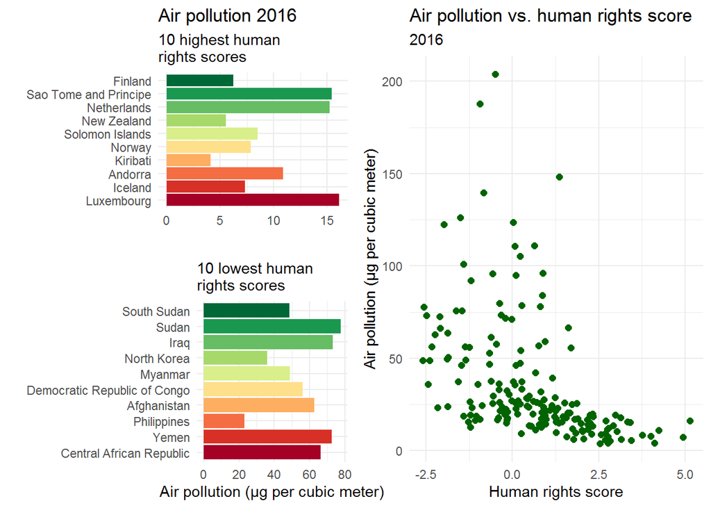

In general, for highest HRS countries there’s a lower abundance in air contamination than for lowest HRS countries. We see this same trend in the scatterplot (a higher HRS generally implies a lower air pollution). Nonetheless, we see countries with deficiency in human rights but with their air pollution in lowest levels, maybe because of lack of resources and/or industrialization.

## Evolution by year

Now, we are interested in plotting the evolution of HRS and air pollution year by year.

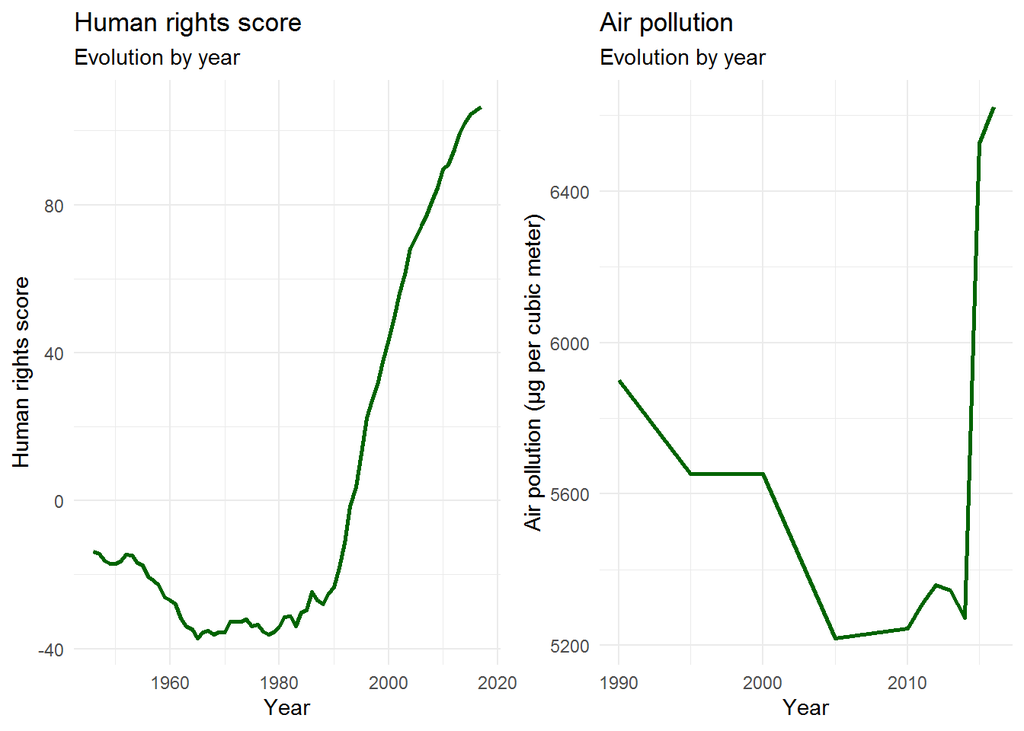

There’s an upward trend for HRS worldwide (fortunately), but we can’t say the same for air pollution in the last 26 years as it almost follows this same tendency.

## Back to 2016

### Distribution of air pollution by HRS level

We are going to make a nominal variable for HRS at 5 different levels: **Very low**, **Low**, **Mid**, **High** and **Very high**. Next, we will see the summary for all them.

```r
# Make nominal variable for HRS
hrs_2016$score_name <- cut(
  hrs_2016$score,
  breaks = 5,
  labels = c('Very low', 'Low', 'Mid', 'High', 'Very high'),
  include.lowest = T)

# Summary by score name
by(hrs_2016, hrs_2016['score_name'], summary)
```

```
## score_name: Very low
##        entity       code                year          score
##  Kenya    : 1   Length:32          Min.   :2016   Min.   :-2.589
##  Thailand : 1   Class :character   1st Qu.:2016   1st Qu.:-2.112
##  Mali     : 1   Mode  :character   Median :2016   Median :-1.599
##  Brazil   : 1                      Mean   :2016   Mean   :-1.741
##  Ukraine  : 1                      3rd Qu.:2016   3rd Qu.:-1.333
##  Venezuela: 1                      Max.   :2016   Max.   :-1.077
##  (Other)  :26
##  air.poll.mean        score_name
##  Min.   : 12.65   Very low :32
##  1st Qu.: 25.72   Low      : 0
##  Median : 50.12   Mid      : 0
##  Mean   : 53.86   High     : 0
##  3rd Qu.: 72.73   Very high: 0
##  Max.   :126.03
##
## ------------------------------------------------------------
## score_name: Low
##               entity       code                year          score
##  Mongolia        : 1   Length:59          Min.   :2016   Min.   :-1.0410
##  Papua New Guinea: 1   Class :character   1st Qu.:2016   1st Qu.:-0.4473
##  Haiti           : 1   Mode  :character   Median :2016   Median :-0.1648
##  Malawi          : 1                      Mean   :2016   Mean   :-0.1730
##  Eswatini        : 1                      3rd Qu.:2016   3rd Qu.: 0.1562
##  Guatemala       : 1                      Max.   :2016   Max.   : 0.4907
##  (Other)         :53
##  air.poll.mean         score_name
##  Min.   :  9.197   Very low : 0
##  1st Qu.: 23.128   Low      :59
##  Median : 30.550   Mid      : 0
##  Mean   : 47.301   High     : 0
##  3rd Qu.: 56.007   Very high: 0
##  Max.   :203.744
##
## ------------------------------------------------------------
## score_name: Mid
##                               entity       code                year
##  Switzerland                     : 1   Length:59          Min.   :2016
##  Marshall Islands                : 1   Class :character   1st Qu.:2016
```

[output cut: 34 more lines]

```
##  Luxembourg     :1   Length:6           Min.   :2016   Min.   :3.759
##  Iceland        :1   Class :character   1st Qu.:2016   1st Qu.:4.032
##  Andorra        :1   Mode  :character   Median :2016   Median :4.170
##  Kiribati       :1                      Mean   :2016   Mean   :4.363
##  Norway         :1                      3rd Qu.:2016   3rd Qu.:4.762
##  Solomon Islands:1                      Max.   :2016   Max.   :5.132
##  (Other)        :0
##  air.poll.mean        score_name
##  Min.   : 4.086   Very low :0
##  1st Qu.: 7.442   Low      :0
##  Median : 8.195   Mid      :0
##  Mean   : 9.125   High     :0
##  3rd Qu.:10.289   Very high:6
##  Max.   :16.097
##
```

It’s clearer now that for `air.poll.mean` the higher the level of HRS, the lower the air pollution concentration.

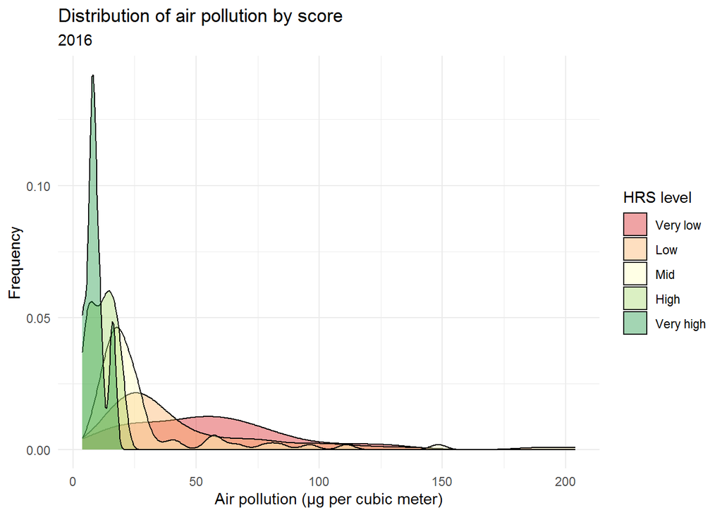

### ANOVA

We are going to make the hypothesis testing that at least one level differs from the others (alternative) in contrast to the hypothesis that all distributions all the same (null) at the level of 0.05.

```r
# ANOVA
anova_mod <- lm(air.poll.mean ~ score_name, hrs_2016)
anova(anova_mod)
```

```
## Analysis of Variance Table
##
## Response: air.poll.mean
##             Df Sum Sq Mean Sq F value    Pr(>F)
## score_name   4  41194 10298.5  11.111 4.505e-08 ***
## Residuals  179 165904   926.8
## ---
## Signif. codes:  0 '***' 0.001 '**' 0.01 '*' 0.05 '.' 0.1 ' ' 1
```

As *p-value* << 0.05, we conclude there’s at least one difference. What this indicates is a possible correlation between HRS and air pollution. As illustrated in the graph, countries with a high HRS remain low in particulate matter emissions in contrast to low HRS countries.

We will see these differences in more detail with a Tukey-Kramer *post-hoc* test.

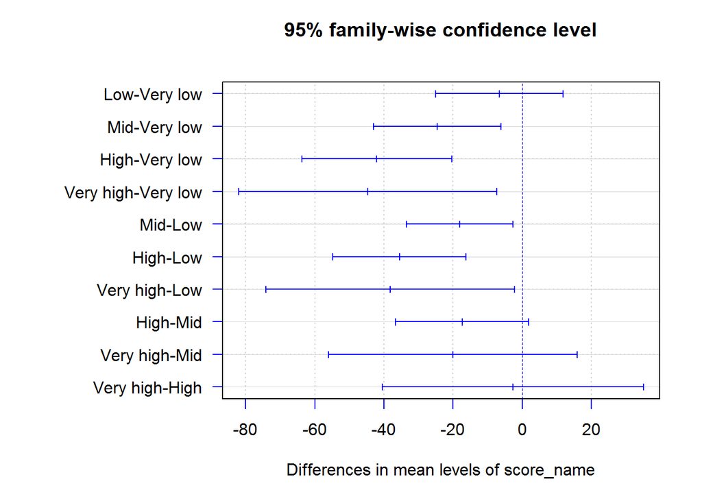

Most differences lie between *Very low* with *Mid*, *High* and *Very high* levels. Also, between *Low* and *Mid*, *High* and *Very high* levels. This indicates that *Very low* and *Low* HRS levels, as we suspect, got higher particulate matter concentration in emissions to the atmosphere.

## Conclusions

Highest HRS countries tend to have the lowest air pollution concentration in comparison with lowest HRS countries. The distribution in concentration for these levels also gets wider meanwhile decreasing in HRS levels.

Increase in HRS in the last years not necessarily indicate that emissions will decrease immediately, as this depends more in successive transition to other kinds of energy applied by economical politics and the interest of citizenship.

## Resources

Baumeister, M. (2019). A white protester showing support by raising his fist for the Black Lives Matter demonstration in Cologne, Germany [Photo]. Köln, Germany. Retrieved from https://unsplash.com/photos/t1tP-Xf8cS4

Fariss, C. J. (2014). Respect for human rights has improved over time: Modeling the changing standard of accountability. *Am. Polit. Sci. Rev.*, *108*(2), 297–318. https://doi.org/10.1017/S0003055414000070

Loonohod, Z. (2019). Rocket launch [Photo]. Retrieved from https://unsplash.com/photos/OUc7GsYU2k4

Ritchie, H., and Roser, M. (2019). Outdoor air pollution. *Our World in Data*. Retrieved from https://ourworldindata.org/outdoor-air-pollution

Roser, M. (2016). Human rights. *Our World in Data*. Retrieved from https://ourworldindata.org/human-rights

Stanaway, J. D., Afshin, A., Gakidou, E., Lim, S. S., Abate, D., Abate, K. H., … Murray, C. J. L. (2018). Global, regional and national comparative risk assessment of 84 behavioural, environmental and occupational, and metabolic risks or clusters of risks for 195 countries and territories, 1990-2017: A systematic analysis for the global burden of disease study 2017. *The Lancet*, *392*(10159), 1923–1994. https://doi.org/10.1016/s0140-6736(18)32225-6